# Waal Intrinsic Variables Project Graph Script

Fionnuala R McCully

25/08/2021

## Wandering Albatross Graph Script

This R Markdown document details the code used to generate the graphs for a study on the impact of intrinsic variables on parental care coordination in wandering albatrosses. It covers the creation of new models suitable for the creation of graphs, the extraction of regression lines from model averaged objects and the creation of the graphs used to display the data.The companion piece to this script is the ‘Waal Model Script.html’ which described the full analysis of this project. This should be consulted before consulting the current document as some knowledge of context is assumed.

## Data Setup

The following code describes the packages used to process the data and uploads the original data files. Three files are provided: `total_df4` which is the full data set, `incu_new2` which features only the incubation data and `brood_new2` which contains only brooding data.

```r
library(MASS)
library(lme4)
library(sjPlot)
library(ggplot2)
library(optimx)
library(MuMIn)
library(dplyr)

total_df4<-read.csv("total_df4.csv")
incu_new2<-subset(total_df4, breed_stage == "incu") # incubation subset, 260 observations
brood_new2<-subset(total_df4, breed_stage== "brood") # brooding subset, 611 observations
```

## Creating new models

The linear mixed models and information theory used during analysis are run again, this time without scaled vraiables to make the resulting graphs more intuative. The results of the following code are hidden for brevity however consult ‘Waal Model Script.html’ for a more detailed account.

First the incubation model is rerun.

```r
# run the incubation model without scaled variables to get regression line, note sqrt response variable
co_ml_incu_r<- lmer(no_hours_sqrt ~
                    sex +
                    #pers +
                    p_pers+
                    age+
                    age_sq +
                    p_age+
                    p_age_sq+
                    NumDays+
                   # new_part+
                    ppb_ave_diff+
                    #age:pers+
                    #age_sq:pers+
                    #age:ppb_ave_diff+
                   # age_sq:ppb_ave_diff+
                  #  pers:ppb_ave_diff+
                    #new_part:ppb_ave_diff+
                   # p_age:p_pers+
                  #  p_age_sq:p_pers+
                  #  p_age:ppb_ave_diff+
                    #p_age_sq:ppb_ave_diff+
                    #p_pers:ppb_ave_diff+
                    (1|cycle) + (1+ppb_ave_diff|cycle_pair),
                  data = incu_new2, na.action=na.fail, REML=FALSE,
                  control=lmerControl (optimizer="optimx",optCtrl=list(method='nlminb')))

summary(co_ml_incu_r)
```

Followed by information theory. the target object of this exercise is `modavm1_incur` which contains the model averaged coefficients which will be used to plot the relevant regression lines.

```r
# dredging to create model set
# linking age variables with their quadratic counterpart so either both or neither are retained
dr_cmin_r<-dredge(co_ml_incu_r, subset = (dc(age, age_sq) &&
                                        dc(p_age, p_age_sq) &&
                                        dc(age_sq, age) &&
                                        dc(p_age_sq, p_age)))
dr_cmin_r # view full model list

# confidence set creation
sub_m1_incu_r<-subset(dr_cmin_r, delta<2) ##subsets models delta >2

# remove nested models
nest_m1_incur <- subset(sub_m1_incu_r, !nested(.)) # removes nested models

#model averaging
modavm1_incur<-model.avg(nest_m1_incur, delta<2, fit = TRUE, revised.var = TRUE) # model averaging, this object is used to get the regression line
```

The process is repeated for the brooding model.

```r
# do exactly the same thing again for the brooding model
co_ml_broodr<- lmer(no_hours_sqrt ~
                    sex +
                    pers +
                    p_pers+
                    age +
                    age_sq +
                    p_age+
                    p_age_sq+
                    #NumDays+
                    new_part+
                    ppb_ave_diff+
                    #age:pers+
                    #age_sq:pers+
                    #age:ppb_ave_diff+
                    #age_sq:ppb_ave_diff+
                    #pers:ppb_ave_diff+
                    #new_part:ppb_ave_diff+
                    #p_age:p_pers+
                    #p_age_sq:p_pers+
                    #p_age:ppb_ave_diff+
                    #p_age_sq:ppb_ave_diff+
                    #p_pers:ppb_ave_diff+
                    (1|cycle) + (1+ppb_ave_diff|cycle_pair),
                  data = brood_new2, na.action=na.fail, REML=FALSE,
                  control=lmerControl (optimizer="optimx",optCtrl=list(method='nlminb')))

summary(co_ml_broodr)
```

In this case, the object `modavm1_broodr` will be used in graph creation.

```r
#dredge creating model set
# linking age variables to their equivalent quadratic version so they can only be discarded or retained together
dr_cmbrr<-dredge(co_ml_broodr, subset = (dc(age, age_sq) &&
                                         dc(p_age, p_age_sq) &&
                                         dc(age_sq, age) &&
                                         dc(p_age_sq, p_age)))
dr_cmbrr # view full model list

# creating confidence set
sub_m1_broodr<-subset(dr_cmbrr, delta<2) ##subsets models delta >2

# removing nested models
nest_m1_broodr <- subset(sub_m1_broodr, !nested(.))# remove nested models

# model averaging
modavm1_broodr<-model.avg(nest_m1_broodr, delta<2, fit = TRUE, revised.var = TRUE) # model averaging, this object will be used to get the regression line for the graphs
```

The final model averaged objects can be viewed below:

```r
# objects will be used to extract regression lines
modavm1_incur # model averaged coefficients for incubation model
```

```
##
## Call:
## model.avg(object = get.models(object = nest_m1_incur, subset = delta <
##     2), revised.var = TRUE)
##
## Component models:
## '1456'  '12356' '146'   '156'   '1236'  '16'
##
## Coefficients:
##        (Intercept)    NumDays     p_pers ppb_ave_diff   sexMale     p_age
## full      7.690455 0.06762461 -0.2064504  0.003978032 -1.394078 0.1800074
## subset    7.690455 0.06762461 -0.4600975  0.006506592 -1.394078 0.6332482
##            p_age_sq
## full   -0.003645709
## subset -0.012825241
```

```r
modavm1_broodr # model averaged coefficients for brooding model
```

```
##
## Call:
## model.avg(object = get.models(object = nest_m1_broodr, subset = delta <
##     2), revised.var = TRUE)
##
## Component models:
## '12345' '2345'
##
## Coefficients:
##        (Intercept)  new_part     p_pers       pers ppb_ave_diff    sexMale
## full      9.009655 0.2716529 -0.2304454 -0.3109039  0.006559795 -0.3510321
## subset    9.009655 0.5040995 -0.2304454 -0.3109039  0.006559795 -0.3510321
```

## Coordination Graph

This graph demonstrates the difference in coordination strength in incubation compared to brooding. This is illustrated by plotting the correlation between individual trip duration (response variable) and their partner’s deviation from average trip duration. The regression lines from both models are extracted to help visualize coordination strength. The stronger the positive slope, the stronger the coordination at the population level.

the setup for this graph is contained within the following section of code. This includes extracting the regression line for the correct variable (partner deviation from average trip duration is labeled as `ppb_ave_diff` in the model).

```r
# coordination graph setup
# getting regression lines from models

mA_inr<-summary(modavm1_incur) # summary incu model
mA_brsq<-summary(modavm1_broodr) #summary brooding model

inDatr <- plot_model(mA_inr, type = "pred", terms = c("ppb_ave_diff")) # extract regression line for incubation, identify predictor variable of interest
```

```
## Error: Confidence intervals could not be computed.
```

```r
inDatr <- data.frame(inDatr$data)

brDatsq <- plot_model(mA_brsq, type = "pred", terms = c("ppb_ave_diff")) # extract regression line for brooding, identify predictor variable of interest
brDatsq <- data.frame(brDatsq$data)
```

The response variable ( individual trip duration or `no_hours_sqrt` in the model) was square root transformed when the analysis was completed. this must be back transformed for the graphs so that the original data can be used and the Y axis units are intuitive.

```r
# Compute the non-square-rooted data for plotting
inDatr.unsqr<- data.frame(x=inDatr$x, predicted=inDatr$predicted^2)
brDatsq.unsqr<- data.frame(x=brDatsq$x, predicted=brDatsq$predicted^2)
```

Changes are also made to the original data set so that incubation and brooding appear on the graph in a logical order. This action will be finalized la little later in the code.

```r
# start process of making incubation and brooding appear on the graph in a logical order
total_df4$breed_stage<- as.character(total_df4$breed_stage)

for (a in 1:(nrow(total_df4))) {
  if (total_df4$breed_stage[a] == "incu")
  {total_df4$breed_stage[a] <- "Incubation"}
  else {total_df4$breed_stage[a] <- "Brooding"}
}

total_df4<-total_df4%>% arrange(total_df4) %>%
  mutate(breed_stage = factor(breed_stage, levels=c("Incubation", "Brooding")))
```

The two breeding stage subsets are combined into a dingle data frame so that `facet_wrap` can be used in `ggplot2` to show incubation and brooding side by side. Final adjustments are made so that so that incubation and brooding appear in an intuitive order with correct labels on the final graph.

```r
# Create a single data frame with both predictions, labeled by the "breed_stage" factor
brDatsq.unsqr $ breed_stage<- "Brooding"
inDatr.unsqr $breed_stage <- "Incubation"
all_preds<- rbind(inDatr.unsqr, brDatsq.unsqr)

#finish process of making incubation and brooding appear in a logical order
all_preds$breed_stage <- factor(all_preds$breed_stage, levels=c("Incubation", "Brooding"), ordered=TRUE) # ordered so that "incu" panel appears on left
```

The graph can then be completed in `ggplot2`.

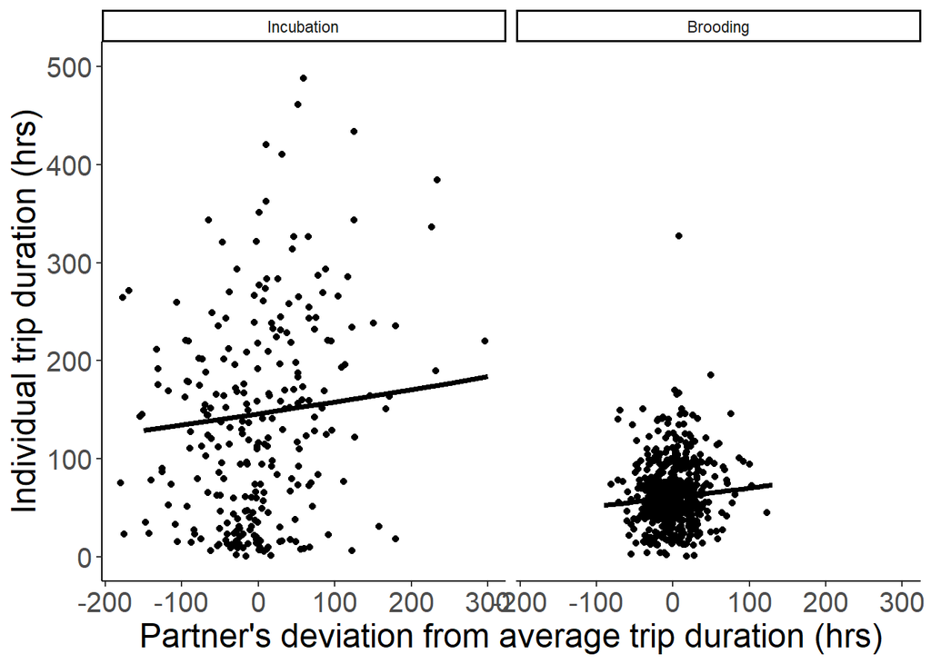

```r
ppb_graph_all<-ggplot( aes(x = x, y = predicted), data = all_preds) +# regression line
  geom_line(size = 1.25)+
  geom_point(aes(x = ppb_ave_diff, y = no_hours), data = total_df4) + # raw data, not using square root
  theme_bw(base_size =15) +
  xlab("Partner's deviation from average trip duration (hrs)")+
  ylab("Individual trip duration (hrs)")+
  facet_wrap(.~breed_stage)+
  xlim(-181, 300)+
  ylim (0, 500)+
  theme_classic()+
  theme(axis.text = element_text(size = 15))+
  theme(axis.title= element_text(size=18))

ppb_graph_all
```

## Focal and Partner Boldness in Brooding Graph

This graph demonstrates that both focal bird boldness (`pers`) and partner bird boldness (`p_pers`) impact individual foraging trip duration during brooding. This graph only requires the brooding data subset (`brood_new2`). It features individual trip duration on the Y axis and boldness score on the x axis. Although the variable `pers` is included in the graph setup, it is used only to set the scale for the x axis, and once the data are hidden, the more generic ‘boldness score’ label can be applied.

In the setup, the regression lines of both `pers` and `p_pers` are extracted so that they might be compared on the graph.

```r
# X axis = boldness score (collective, both focal and partner), Y axis =individual trip duration, brooding only, colour = focal or partner

mA_brsq<-summary(modavm1_broodr) #summary brooding model

brDatpers <- plot_model(mA_brsq, type = "pred", terms = c("pers")) # extract regression line for pers
brDatpers <- data.frame(brDatpers$data)

brDatp_pers <- plot_model(mA_brsq, type = "pred", terms = c("p_pers")) # extract regression line for p_pers
brDatp_pers <- data.frame(brDatp_pers$data)
```

The response variable is back-transformed, and the confidence intervals are similarly adjusted so they can be used on the graph in the correct scale.

```r
# Compute the non-square-rooted pers data for plotting
brpers_unsqr<- data.frame(x=brDatpers$x, predicted=brDatpers$predicted^2,se=brDatpers$std.error, cih = brDatpers$conf.high^2, cil =brDatpers$conf.low^2)
brp_pers_unsqr<- data.frame(x=brDatp_pers$x, predicted=brDatp_pers$predicted^2, se=brDatp_pers$std.error, cih = brDatp_pers$conf.high^2, cil =brDatp_pers$conf.low^2)
```

The graph is then created in ggplot. Note how the data points are hidden to legitimise the ‘boldness score’ x axis label and the request for specific x axis increments which may generate a harmless warning.

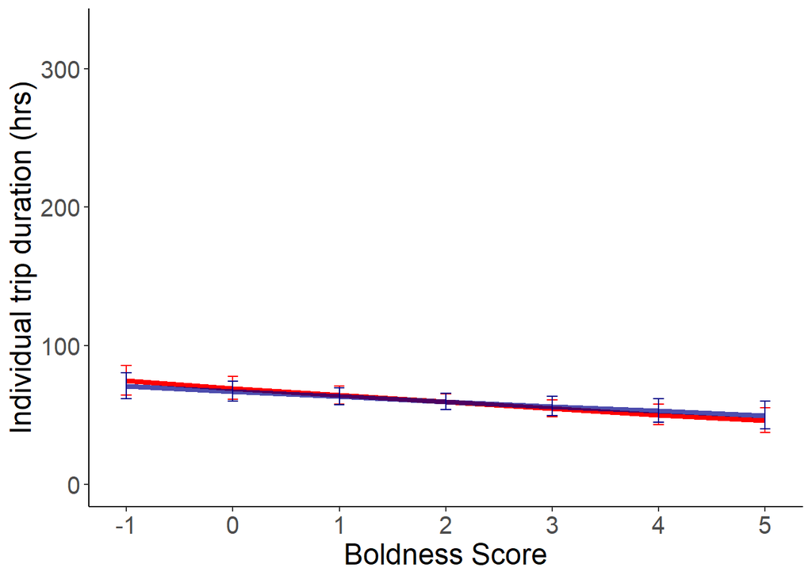

```r
# create pers brooding graph
pers_graph_com<-ggplot(aes(x = x, y = predicted), data = brpers_unsqr) +# regression line for pers variable
  geom_line(size = 1.5, colour = "red")+
  geom_errorbar(aes(ymin=cil, ymax=cih), width=.1, colour = "red") +
  geom_line(aes(x = x, y = predicted), data = brp_pers_unsqr, size =1.5, colour = "dark blue", alpha = 0.7) +# regression line for p_pers variable
  geom_point(aes(x = pers, y = no_hours), data = brood_new2, alpha = 0.0) + # hide data point to validate x axis, using pers variable creates correct scale for both variables but will not feature in final plot
  geom_errorbar(data =brp_pers_unsqr, aes(ymin=cil, ymax=cih), width=.1, colour = "dark blue") +
  theme_bw(base_size =15) +
  xlab("Boldness Score")+
  ylab("Individual trip duration (hrs)")+
  xlim(-1, 5)+
  ylim (0, 327)+
  theme_classic()+
  scale_x_continuous(breaks=c(-1, 0, 1, 2, 3, 4, 5))+
  theme(axis.text = element_text(size = 15))+
  theme(axis.title= element_text(size=18))

pers_graph_com
```

## Partner Age in Incubation Graph

The final graph displays the weak quadratic relationship between partner age and individual foraging trip duration during incubation. Only `incu_new2` is needed for this graph as it only concerns the incubation data. individual trip duration is once again featured on the Y axis while partner age is on the x axis. the variable extracted from the model is `p_age_sq`; the quadratic term representing partner age in the original model. Once again the data points will be hidden in the final graph.

```r
# x axis = partner age, y axis = individual trip duration, incubation only

# extract regression line
mA_inr<-summary(modavm1_incur)
age_dat <- plot_model(mA_inr, type = "pred", terms = c("p_age_sq"))
```

```
## Error: Confidence intervals could not be computed.
```

```r
age_dat<- data.frame(age_dat$data)
```

The response variable is back-transformed and the square root of the predictor is calculated so they are on intuative scales

```r
# non-square root data for plotting
age_dat<- age_dat%>% mutate(age_dat, age_new = (sqrt(x))) # calculate square root of age
age_dat.unsqr<- data.frame(x=age_dat$x, age_dat$age_new, predicted=age_dat$predicted^2) # untransform response variable
```

Finally, the graph is created. Note the hidden data points and he request for specific x axis increments which may generate a harmless warning.

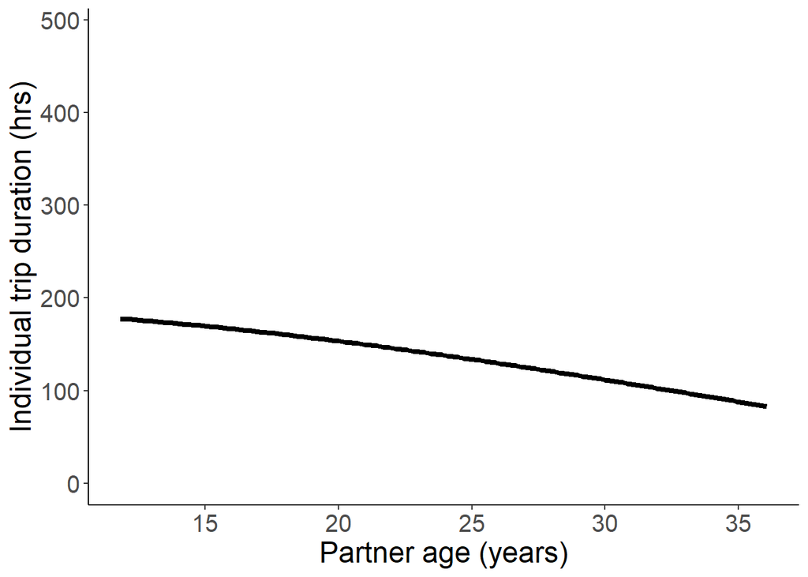

```r
p_ageincu_graph<-ggplot( aes(x = age_dat.age_new, y = predicted), data = age_dat.unsqr)+# regression line
  geom_line(size = 1.5)+
  geom_point(aes(x = p_age, y = no_hours), data = incu_new2, alpha = 0.0)+ # hides data points
  theme_bw(base_size =15) +
  xlab("Partner age (years)")+
  ylab("Individual trip duration (hrs)")+
  theme(panel.grid.major = element_blank(), panel.grid.minor = element_blank())+
  scale_x_continuous(breaks=c(10, 15, 20, 25, 30, 35, 40))+
  theme_classic()+
  theme(axis.text = element_text(size = 15))+
  theme(axis.title= element_text(size=18))


p_ageincu_graph
```